# Obtaining TRI Data

Marc Los Huertos

8/8/2016

## TRI Data

What is TRI? According to the EPA, “TRI is a resource for learning about toxic chemical releases and pollution prevention activities reported by industrial and federal facilities. TRI data support informed decision-making by communities, government agencies, companies, and others.”

Before doing too much on TRI, you will find reading this is very helpful [“Factors to Consider”](https://www.epa.gov/toxics-release-inventory-tri-program/factors-consider-when-using-toxics-release-inventory-data), which you can find in English or Spanish.

## Numerous Ways to Get Data

The TRI database is in a structured query database or SQL, which means data tables are linked by key words. Unfortunately, SQL has complex syntax and learning it is well beyond the scope of this course. So, we have to use the TRI interface, which allows users to obtain data from the database. Unfortunately, there are several ways to get the data and each of the methods have their own challenges.

I have a few suggestions below, but if you find a better way, please share them with us, using this document.

### Using TRI Explorer

1. Check out fact sheet page:

https://iaspub.epa.gov/triexplorer/tri_factsheet_search.searchfactsheet

This page gives you a sampling of what has been reported. I suggest you check out a range of zip codes or even some particular chemicals.

For example, we might check out [Aniline in the USA](https://iaspub.epa.gov/triexplorer/chemical.html?pYear=2015&pLoc=000062533&pParent=TRI&pDataSet=TRIQ1). Aniline, of course, is famous because of it’s role as a dye and use at the Toms River Chemical Company, Cinnicinati Chemical Company, and even Basal, Switzerland.

Another approach is to evaluate various sites in a region. EPA has devided the country (and territories) into regions. We happend to be in Region 9. Thus, we might select facilities [region 9](https://iaspub.epa.gov/triexplorer/region.html?pYear=2015&pLoc=9&pParent=TRI&pDataSet=TRIQ1)), where the 5Cs are located.

2. Evaluate Release Reports

Before you select a Facility, it might be useful to determine if the toxics released pose a potential risk.

-We might evaluate what [chemicals](https://iaspub.epa.gov/triexplorer/tri_release.chemical) might be released. This is useful if you have a specific interest in a chemical that you think is a particular risk.

-Alternatively, we might explore facilities that might be releasing chemicals. This might be preferrable because we can narrow our search to areas or communities that might be particularly vulnerable.

Below is a screen shot of this facilities interface. If you decide to make use of this site, be sure to include the longitude and latitude, so we can map the site later on in the project.

[figure not shown]

screen

3. Selecting a Facility

Begin by looking over all the data for a county or zip code. Evaluate the chemicals released by using a search engine to determine a site may be a signficiant risk. Of course, you’ll need to decided which release type is most compelling to you. Most students focus on “Fugitive Air” releases. But stake maybe more important.

I found a facility (Gallade Chemical Inc) in Orange County that had a wide range of chemicals released as “Fugitative Air”.

4. Download the Facilities records.

Following my selection, I double check to see if this the site I am really interested.

To download all the data, navigate to the bottom of the page, and notice a tiny button that says “Download all data”, which will create a csv file. Save this file in some locations on your computer that you can find again!

5. Preprocessing Data

To read this into R, we have to pre-process the data abit. For example, the first two rows need to be removed or R won’t create the headers correctly. NOTE: I found that I had to fix another issue in some files, you can see what I had to do below and check your file now, or follow along and hope that you don’t have the same problem I had.

Once you have done this, upload the csv file into R, using the “upload” button" in R (The “Upload” button is located on the “Files” table in the lower right window of Rstudio. I suggest you nativgate to your own directory and then upload, so you know exactly where you have saved it.

### Importing the Facility Data into R

There are three steps to download data into R:

1. Identify the path and file name (We can use ‘file.choose()’)
2. Read the file into R (‘read.csv()’).
3. Create an object (dataframe) in R to be analyzed ( ‘<-’).

Here’s an example:

first, I use file.choose() to find my file and copy the path/file name into the clipboard.

> file.choose()

[1] “/home/CAMPUS/mwl04747/github/Environmental_Hazards/GALLADE CHEMICAL INC.csv”

We can then create a short cut to the long file name and then read the file into a data frame, called import.

```r
file = "/home/CAMPUS/mwl04747/github/Environmental_Hazards/GALLADE CHEMICAL INC.csv"
import <- read.csv(file)
```

I always check the data to see that the file was read correctly, by looking at the structure (‘str()’) and first six observations or header (‘head()’).

```r
str(import)
```

```
## 'data.frame':    214 obs. of  37 variables:
##  $ Facility.name                                : Factor w/ 1 level "GALLADE CHEMICAL INC": 1 1 1 1 1 1 1 1 1 1 ...
##  $ TRI.ID                                       : Factor w/ 1 level "92707GLLDC1230E": 1 1 1 1 1 1 1 1 1 1 ...
##  $ Address                                      : Factor w/ 1 level "1230 E SAINT GERTRUDE PL": 1 1 1 1 1 1 1 1 1 1 ...
##  $ City                                         : Factor w/ 1 level "SANTA ANA": 1 1 1 1 1 1 1 1 1 1 ...
##  $ County                                       : Factor w/ 1 level "ORANGE": 1 1 1 1 1 1 1 1 1 1 ...
##  $ State                                        : Factor w/ 1 level "CA": 1 1 1 1 1 1 1 1 1 1 ...
##  $ Zip.Code                                     : Factor w/ 1 level "'92707'": 1 1 1 1 1 1 1 1 1 1 ...
##  $ Year                                         : int  1988 1988 1988 1988 1988 1988 1988 1988 1988 1988 ...
##  $ Chemical                                     : Factor w/ 22 levels "1,1,1-TRICHLOROETHANE",..: 1 2 3 4 7 8 12 14 15 16 ...
##  $ CAS                                          : Factor w/ 22 levels "'000050000'",..: 7 5 20 8 9 18 10 22 19 16 ...
##  $ Federal..F..or.Commercial..C.                : Factor w/ 1 level "C": 1 1 1 1 1 1 1 1 1 1 ...
##  $ Form.Type..Form.R.or.A.                      : Factor w/ 2 levels "R","S": 1 1 1 1 1 1 1 1 1 1 ...
##  $ Industry                                     : Factor w/ 2 levels "NAICS 325 - Chemicals",..: 1 1 2 1 1 1 1 2 1 1 ...
##  $ Fugitive.Air                                 : Factor w/ 8 levels ".","0","250",..: 3 3 3 3 3 3 3 3 3 3 ...
```

[output cut: 23 more lines]

```r
head(import)
```

```
##          Facility.name          TRI.ID                  Address      City
## 1 GALLADE CHEMICAL INC 92707GLLDC1230E 1230 E SAINT GERTRUDE PL SANTA ANA
## 2 GALLADE CHEMICAL INC 92707GLLDC1230E 1230 E SAINT GERTRUDE PL SANTA ANA
## 3 GALLADE CHEMICAL INC 92707GLLDC1230E 1230 E SAINT GERTRUDE PL SANTA ANA
## 4 GALLADE CHEMICAL INC 92707GLLDC1230E 1230 E SAINT GERTRUDE PL SANTA ANA
## 5 GALLADE CHEMICAL INC 92707GLLDC1230E 1230 E SAINT GERTRUDE PL SANTA ANA
## 6 GALLADE CHEMICAL INC 92707GLLDC1230E 1230 E SAINT GERTRUDE PL SANTA ANA
##   County State Zip.Code Year
## 1 ORANGE    CA  '92707' 1988
## 2 ORANGE    CA  '92707' 1988
## 3 ORANGE    CA  '92707' 1988
## 4 ORANGE    CA  '92707' 1988
## 5 ORANGE    CA  '92707' 1988
## 6 ORANGE    CA  '92707' 1988
##                                                Chemical         CAS
```

[output cut: 83 more lines]

In this case, R did not import the file correctly. The amounts of releases have been imported as factors, thus not continuous variables. Bummer… so, now I need to sort out what went wrong.

As I looked at “import” I noticed some entries that were just ‘.’. R didn’t know how to import these (their not numbers!), so it defaulted to make all the variables as text strings, which are then seen as factors in the dataframe.

So, in excel, I did a search and replace to find all the ‘.’ (be sure to select matching for entire cells) and then replaced with ‘NA’, which R understands as missing data. I guess you could also put in zero, which would be more accurate, but I didn’t think of that until now.

Now, I re-read the new, uploaded csv file.

```r
file = "/home/CAMPUS/mwl04747/github/Environmental_Hazards/GALLADE CHEMICAL INC (1).csv"
import <- read.csv(file)
str(import)
```

```
## 'data.frame':    214 obs. of  37 variables:
##  $ Facility.name                                : Factor w/ 1 level "GALLADE CHEMICAL INC": 1 1 1 1 1 1 1 1 1 1 ...
##  $ TRI.ID                                       : Factor w/ 1 level "92707GLLDC1230E": 1 1 1 1 1 1 1 1 1 1 ...
##  $ Address                                      : Factor w/ 1 level "1230 E SAINT GERTRUDE PL": 1 1 1 1 1 1 1 1 1 1 ...
##  $ City                                         : Factor w/ 1 level "SANTA ANA": 1 1 1 1 1 1 1 1 1 1 ...
##  $ County                                       : Factor w/ 1 level "ORANGE": 1 1 1 1 1 1 1 1 1 1 ...
##  $ State                                        : Factor w/ 1 level "CA": 1 1 1 1 1 1 1 1 1 1 ...
##  $ Zip.Code                                     : Factor w/ 1 level "'92707'": 1 1 1 1 1 1 1 1 1 1 ...
##  $ Year                                         : int  1988 1988 1988 1988 1988 1988 1988 1988 1988 1988 ...
##  $ Chemical                                     : Factor w/ 22 levels "1,1,1-TRICHLOROETHANE",..: 1 2 3 4 7 8 12 14 15 16 ...
##  $ CAS                                          : Factor w/ 22 levels "'000050000'",..: 7 5 20 8 9 18 10 22 19 16 ...
##  $ Federal..F..or.Commercial..C.                : Factor w/ 1 level "C": 1 1 1 1 1 1 1 1 1 1 ...
##  $ Form.Type..Form.R.or.A.                      : Factor w/ 2 levels "R","S": 1 1 1 1 1 1 1 1 1 1 ...
##  $ Industry                                     : Factor w/ 2 levels "NAICS 325 - Chemicals",..: 1 1 2 1 1 1 1 2 1 1 ...
##  $ Fugitive.Air                                 : int  250 250 250 250 250 250 250 250 250 250 ...
```

[output cut: 23 more lines]

## Analyzing Data

As we begin the analysis program, I often have to refer back to the file to remember the names of the variables, which in this case are hard to remember. I can also elect to change the names to make them simpilar, which I will do in an updated version if it’s useful.

```r
names(import)
```

```
##  [1] "Facility.name"
##  [2] "TRI.ID"
##  [3] "Address"
##  [4] "City"
##  [5] "County"
##  [6] "State"
##  [7] "Zip.Code"
##  [8] "Year"
##  [9] "Chemical"
## [10] "CAS"
## [11] "Federal..F..or.Commercial..C."
## [12] "Form.Type..Form.R.or.A."
## [13] "Industry"
## [14] "Fugitive.Air"
## [15] "Stack.Air"
```

[output cut: 22 more lines]

### Creating a Time Series

So, making plots is easy in R. In this case, I’ll see what fugitive air releases have changed with time.

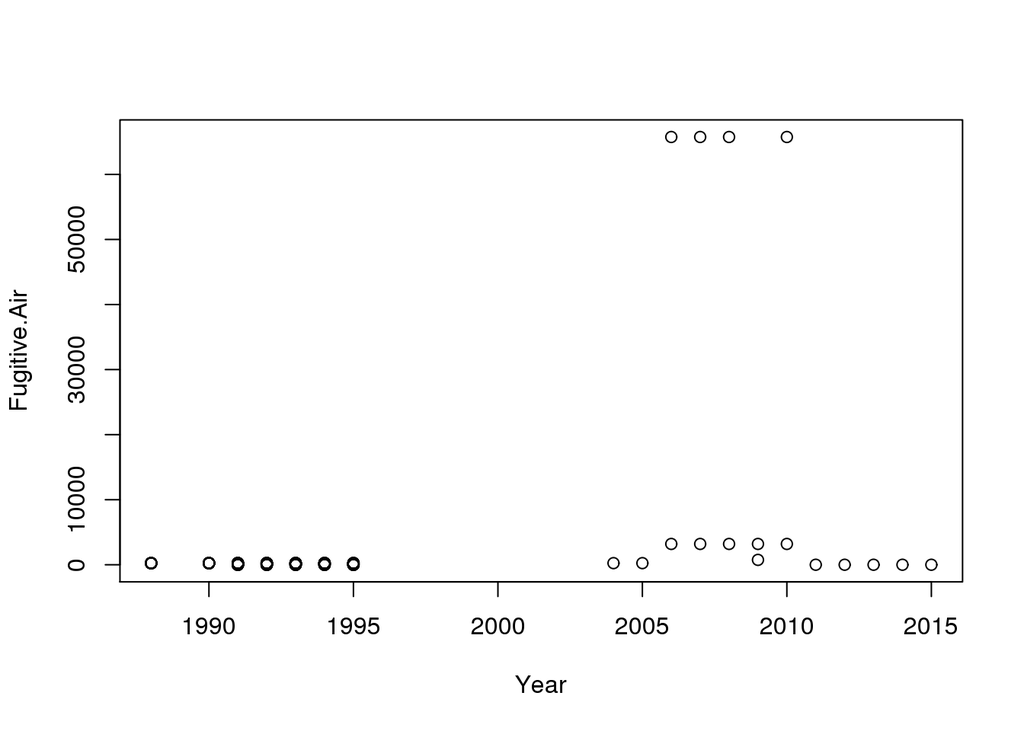

```r
plot(Fugitive.Air  ~ Year, data=import)
```

### Subsetting Data

First, I need a list of chemicals so I can sort through each of them. I know the variable name is ‘Chemical’, but how can I create a vector of the unique types, let’s use the function ‘unique()’, where we specifie the dataframe and the variable name:

```r
unique(import$Chemical)
```

```
##  [1] 1,1,1-TRICHLOROETHANE
##  [2] ACETONE
##  [3] AMMONIA
##  [4] DICHLOROMETHANE
##  [5] FREON 113
##  [6] HYDROCHLORIC ACID (1995 AND AFTER ACID AEROSOLS ONLY)
##  [7] METHYL ETHYL KETONE
##  [8] NITRIC ACID
##  [9] PHOSPHORIC ACID
## [10] SODIUM HYDROXIDE (SOLUTION)
## [11] SULFURIC ACID (1994 AND AFTER ACID AEROSOLS ONLY)
## [12] TETRACHLOROETHYLENE
## [13] ETHYLENE GLYCOL
## [14] FORMALDEHYDE
## [15] HYDROQUINONE
## [16] METHANOL
## [17] N-BUTYL ALCOHOL
## [18] THIOUREA
## [19] TOLUENE
## [20] TRICHLOROETHYLENE
## [21] XYLENE (MIXED ISOMERS)
## [22] ISOPROPYL ALCOHOL (MANUFACTURING,STRONG-ACID PROCESS ONLY,NO SUPPLIER)
## 22 Levels: 1,1,1-TRICHLOROETHANE ACETONE AMMONIA ... XYLENE (MIXED ISOMERS)
```

Notice they are all upper case and in some cases quite long, thus easy to mispell. I like to copy and paste each name so I can create a figure without too much consternation based on my typing ability.

First, let’s see how to subset a dataframe, using the function ‘subset()’

```r
xylene <- subset(import, Chemical=="XYLENE (MIXED ISOMERS)")
```

NOTE: The double ‘==’ is a bizarre syntax!

Now, we can plot xylene,

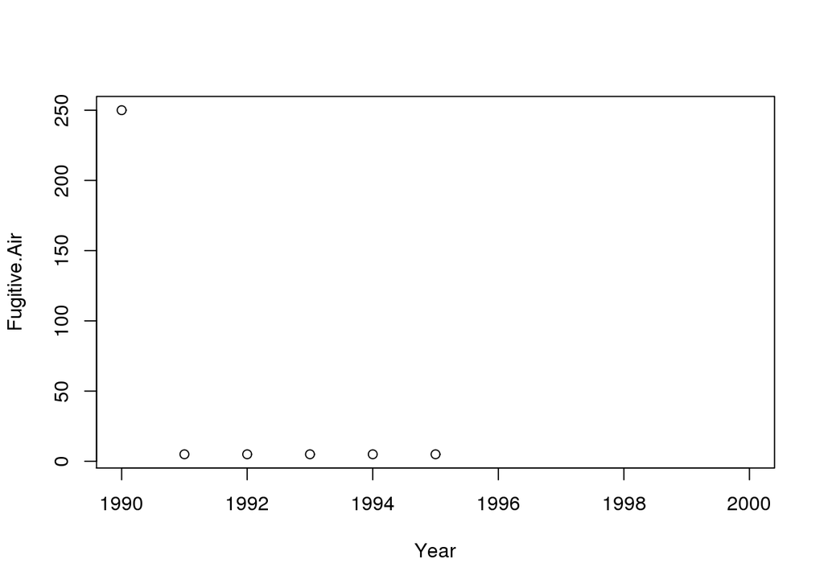

```r
plot(Fugitive.Air  ~ Year, data=xylene)
```

Super uneven releases, this might be worth investigating. But for now, let’s turn to the census data for the area around the facility.

## Combining with Census Data

```r
library(UScensus2010)
library(UScensus2010tract)
```

Let’s first look a bit at the data. For example, what are the counties in California that might be available?

First, we need to learn something about how the federal government sorts out county and state codes. They do this using FIPS. The FIPS county code is a five-digit Federal Information Processing Standard (FIPS) code (FIPS 6-4) which uniquely identifies counties and county equivalents in the United States, certain U.S. possessions, and certain freely associated states. The first two digits are the FIPS state code and the last three are the county code within the state or possession.

we can query the county codes for California with the following:

```r
data(countyfips)
# Just doing the first six with the 'head()' function
head(countyfips[countyfips$statename=="california",])
```

```
##      fips       countyname  statename acronym
## 185 06001   alameda county california      ca
## 186 06003    alpine county california      ca
## 187 06005    amador county california      ca
## 188 06007     butte county california      ca
## 189 06009 calaveras county california      ca
## 190 06011    colusa county california      ca
```

Since, my site is in Orange county, I’m going to start there, which has a FIPS code of 06059.

The address of the facility is 1230 E SAINT GERTRUDE PL, SANTA ANA, CALIFORNIA 92707

```r
#countyfips[countyfips$statename=="california",]

### The county fips code is the last three characters
county.f<-"002" # Not sure what this is for!
county.n<-c("orange county", "los angeles county")

## Pull out these counties
c1<-county(fips=county.f,state="ca",level="tract")
```

```
## Not a valid county FIPS!
```

```r
c2<-county(name=county.n,state="ca",level="tract")
```

## Plot counties

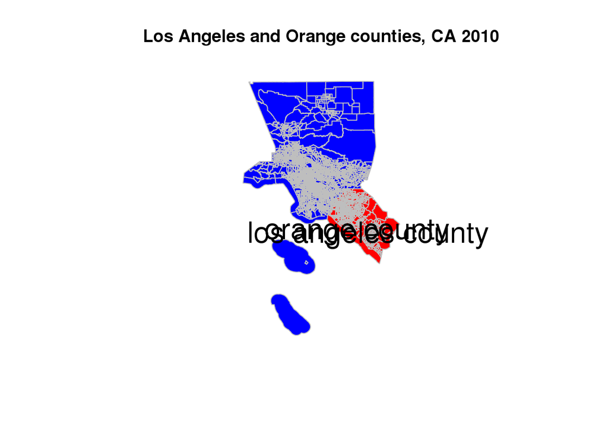

```r
california.counties<-countyfips[countyfips$statename=="california",]
col<-cbind(c("red","blue"),c("059","037"))
plot(c2,col=col[match(c2$county,col[,2]),1],border="gray")
title("Los Angeles and Orange counties, CA 2010")
coord<-coordinates(c2)
text(coord[c(1,4),],california.counties$countyname[california.counties$countyname%in%county.n],cex=2)
```

## Demographics

I found the tract nearest the facility to be 743 via google, and that it is 85% Latino!

I am working on how to get the R GIS data to cooperate to create a map, but for now, this is a great start.

data(“california.tract10”)

head(demographics(dem=c(“P0010001”), state=“ca”,level=“tract”))

# Alternative Approach Importing the data (Use at your own Risk!)

- Data has some problems. First, there are multiple entries per site. As R make some guesses about how to read the data, this creates several problems.

```r
LA2015 <- read.csv("/home/CAMPUS/mwl04747/github/Environmental_Hazards/Data/fac_release2015_2.csv");

str(LA2015)
```

```
## 'data.frame':    487 obs. of  72 variables:
##  $ Row..           : Factor w/ 110 levels " ","<u>How to cite TRI Explorer.</u>    Following APA Style, 6th edition, an appropriate citation to TRI Explorer is:<br/>United St"| __truncated__,..: 3 1 1 15 1 26 1 37 1 48 ...
##  $ Facility        : Factor w/ 213 levels ""," ","1,2,4-TRIMETHYLBENZENE",..: 8 205 212 9 118 12 160 13 160 14 ...
##  $ Latitude        : Factor w/ 99 levels ""," ","33.738",..: 76 2 2 75 2 30 2 30 2 12 ...
##  $ Longitude       : Factor w/ 98 levels ""," ","-117.729",..: 13 2 2 15 2 59 2 60 2 36 ...
##  $ Underground     : Factor w/ 7 levels "",".","**","0",..: 4 4 4 4 4 4 4 4 4 4 ...
##  $ RCRA.Subtitle   : Factor w/ 6 levels "",".","**","0",..: 4 4 4 4 4 4 4 4 4 4 ...
##  $ Other.On.Site   : Factor w/ 6 levels "",".","**","0",..: 4 4 4 4 4 4 4 4 4 4 ...
##  $ Sub.Total       : Factor w/ 5 levels "",".","**","0",..: 4 4 4 4 4 4 4 4 4 4 ...
##  $ Fugitive.Air    : Factor w/ 182 levels "",".","**","0",..: 4 4 4 4 4 4 4 4 4 4 ...
##  $ Point.Source    : Factor w/ 194 levels "",".","**","0",..: 181 173 188 157 157 4 4 4 4 4 ...
##  $ Surface.Water   : Factor w/ 46 levels "",".","**","0",..: 4 4 4 7 7 4 4 4 4 4 ...
##  $ Underground.1   : Factor w/ 8 levels "",".","**","0",..: 4 4 4 4 4 4 4 4 4 4 ...
##  $ Land.Treatment  : Factor w/ 5 levels "",".","**","0",..: 4 4 4 4 4 4 4 4 4 4 ...
##  $ RCRA.Subtitle.1 : Factor w/ 7 levels "",".","**","0",..: 4 4 4 4 4 4 4 4 4 4 ...
```

[output cut: 58 more lines]

```r
#with(LA2015, plot(Longitude, Latitude))
```

## Facility Data

I have downloaded data using, https://www.epa.gov/toxics-release-inventory-tri-program/tri-basic-data-files-calendar-years-1987-2014 and selecting 2014 data.

```r
TRI14CAsource <- "/home/CAMPUS/mwl04747/github/Environmental_Hazards/Data/TRI_2014_CA.csv"
TRI14CA <- read.csv(TRI14CAsource); str(TRI14CA)
```

```
## 'data.frame':    3893 obs. of  109 variables:
##  $ YEAR                           : int  2014 2014 2014 2014 2014 2014 2014 2014 2014 2014 ...
##  $ TRI_FACILITY_ID                : Factor w/ 1288 levels "90001BCNCX935E5",..: 171 569 883 118 1229 380 282 414 182 275 ...
##  $ FRS_ID                         : num  1.1e+11 1.1e+11 1.1e+11 1.1e+11 1.1e+11 ...
##  $ FACILITY_NAME                  : Factor w/ 1167 levels "3M CO - CORONA",..: 809 1083 242 453 928 1018 324 1135 150 782 ...
##  $ STREET_ADDRESS                 : Factor w/ 1286 levels "1 FEDERAL WAY",..: 801 1197 380 63 247 845 794 370 49 417 ...
##  $ CITY                           : Factor w/ 319 levels "ADELANTO","ALPAUGH",..: 282 118 54 266 141 81 8 188 251 148 ...
##  $ COUNTY                         : Factor w/ 49 levels "ALAMEDA","AMADOR",..: 15 30 16 15 25 15 15 30 15 15 ...
##  $ ST                             : Factor w/ 1 level "CA": 1 1 1 1 1 1 1 1 1 1 ...
##  $ ZIP                            : int  90503 92345 93610 90280 95648 91731 91006 91761 90670 90813 ...
##  $ BIA_CODE                       : logi  NA NA NA NA NA NA ...
##  $ TRIBE                          : logi  NA NA NA NA NA NA ...
##  $ LATITUDE                       : num  33.8 34.4 37.1 33.9 NA ...
##  $ LONGITUDE                      : num  -118 -117 -120 -118 NA ...
##  $ FEDERAL_FACILITY               : Factor w/ 2 levels "NO","YES": 1 1 1 1 1 1 1 1 1 1 ...
```

[output cut: 86 more lines]

Let’s evaluate the variable names and see what we have:

```r
names(TRI14CA)
```

```
##   [1] "YEAR"                            "TRI_FACILITY_ID"
##   [3] "FRS_ID"                          "FACILITY_NAME"
##   [5] "STREET_ADDRESS"                  "CITY"
##   [7] "COUNTY"                          "ST"
##   [9] "ZIP"                             "BIA_CODE"
##  [11] "TRIBE"                           "LATITUDE"
##  [13] "LONGITUDE"                       "FEDERAL_FACILITY"
##  [15] "INDUSTRY_SECTOR_CODE"            "INDUSTRY_SECTOR"
##  [17] "PRIMARY_SIC"                     "SIC_2"
##  [19] "SIC_3"                           "SIC_4"
##  [21] "SIC_5"                           "SIC_6"
##  [23] "PRIMARY_NAICS"                   "NAICS_2"
##  [25] "NAICS_3"                         "NAICS_4"
##  [27] "NAICS_5"                         "NAICS_6"
##  [29] "DOC_CTRL_NUM"                    "CHEMICAL"
```

[output cut: 40 more lines]

## Filter for LA County

```r
library(dplyr)
TRI14LA <-  TRI14CA %>% filter(COUNTY == "LOS ANGELES")
```

## Map Sites

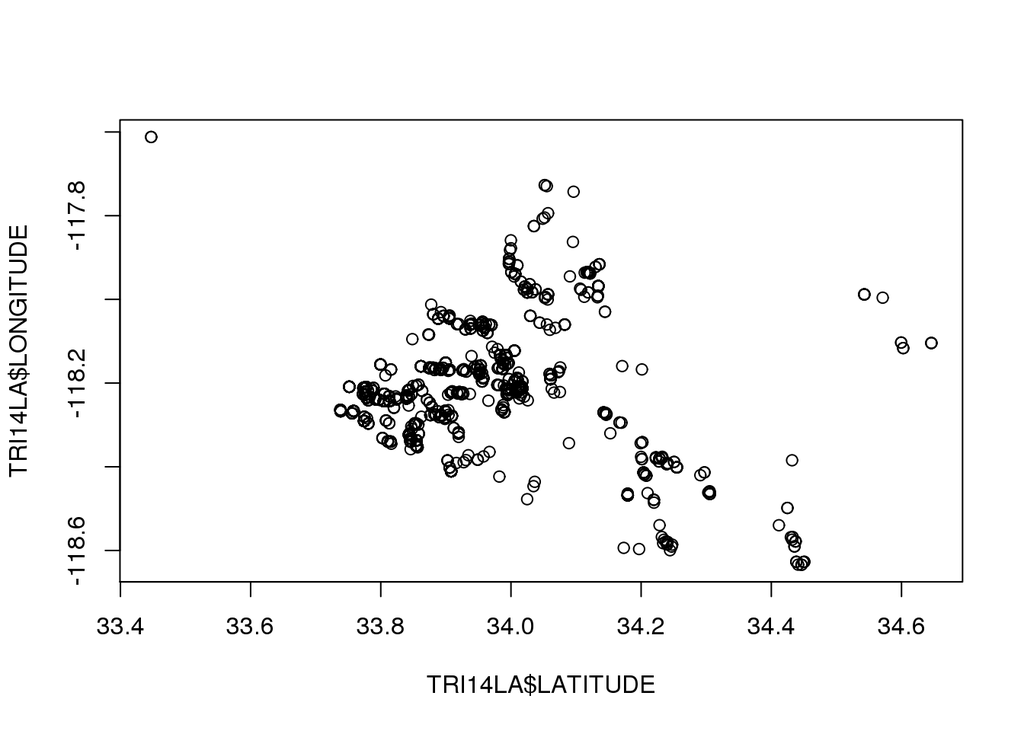

```r
plot(TRI14LA$LATITUDE, TRI14LA$LONGITUDE)
```